# IE 360 - HW 3

## 3.3 Task 3 (AR Model)

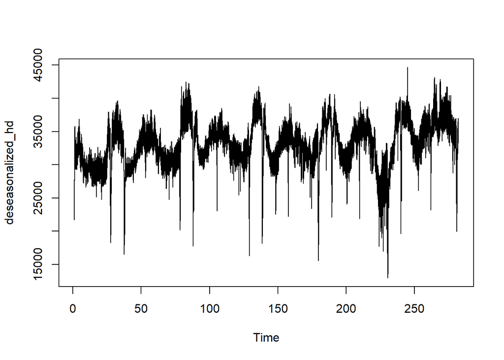

```r
deseasonalized_hd <- ts_hd-decomposed_hd$seasonal
plot(deseasonalized_hd)
```

Deseasonalized series still exhibit some level of seasonality. That is because we chose the frequency 168 (`24*7`), but the consumption data also may have monthly etc. seasonality.

Removing the trend: (It is the same with accessing the random component of the decomposed object)

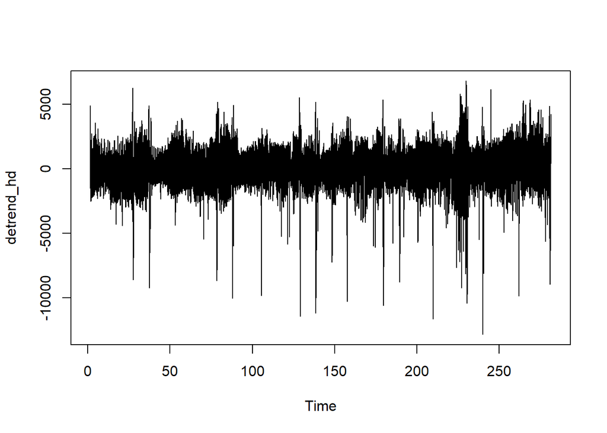

```r
detrend_hd <- deseasonalized_hd-decomposed_hd$trend
ts.plot(detrend_hd)
```

```r
AIC_vector <- vector()
model_ar <- arima(random_hd, order = c(1,0,0))
AIC_vector <- append(AIC_vector, AIC(model_ar))
summary(model_ar)
```

```
##
## Call:
## arima(x = random_hd, order = c(1, 0, 0))
##
## Coefficients:
##          ar1  intercept
##       0.9236    -1.0772
## s.e.  0.0018    34.2930
##
## sigma^2 estimated as 322651:  log likelihood = -365083.2,  aic = 730172.4
##
## Training set error measures:
##                      ME     RMSE      MAE       MPE     MAPE      MASE
## Training set 0.01167853 568.0237 420.5019 -109.3722 398.3928 0.9820777
##                   ACF1
## Training set 0.4811209
```

```r
model_ar2 <- arima(random_hd, order = c(2,0,0))
AIC_vector <- append(AIC_vector, AIC(model_ar2))
summary(model_ar2)
```

```
##
## Call:
## arima(x = random_hd, order = c(2, 0, 0))
##
## Coefficients:
##          ar1      ar2  intercept
##       1.4047  -0.5215    -1.0783
## s.e.  0.0039   0.0039    19.1362
##
## sigma^2 estimated as 234926:  log likelihood = -357620.6,  aic = 715249.2
##
## Training set error measures:
##                      ME     RMSE      MAE       MPE     MAPE      MASE
## Training set 0.01319936 484.6915 350.6825 -47.34639 305.6878 0.8190153
##                    ACF1
## Training set 0.02971392
```

AIC decreased relative to order 1 autoregressive model. Let’s try a higher order:

```r
model_ar3 <- arima(random_hd, order = c(3,0,0))
AIC_vector <- append(AIC_vector, AIC(model_ar3))
summary(model_ar3)
```

```
##
## Call:
## arima(x = random_hd, order = c(3, 0, 0))
##
## Coefficients:
##          ar1      ar2     ar3  intercept
##       1.4345  -0.6019  0.0572    -1.0785
## s.e.  0.0046   0.0076  0.0046    20.2570
##
## sigma^2 estimated as 234157:  log likelihood = -357543.5,  aic = 715097
##
## Training set error measures:
##                     ME     RMSE     MAE       MPE     MAPE      MASE
## Training set 0.0131231 483.8977 350.689 -33.84703 292.0167 0.8190304
##                     ACF1
## Training set 0.003038007
```

AIC decreased by only a very small amount.

```r
model_ar4 <- arima(random_hd, order=c(4,0,0))
AIC_vector <- append(AIC_vector, AIC(model_ar4))
summary(model_ar4)
```

```
##
## Call:
## arima(x = random_hd, order = c(4, 0, 0))
##
## Coefficients:
##          ar1      ar2     ar3      ar4  intercept
##       1.4377  -0.6348  0.1358  -0.0548    -1.0778
## s.e.  0.0046   0.0080  0.0080   0.0046    19.1842
##
## sigma^2 estimated as 233454:  log likelihood = -357472.8,  aic = 714957.6
##
## Training set error measures:
##                      ME     RMSE      MAE       MPE     MAPE      MASE
## Training set 0.01269647 483.1713 349.9102 -42.43647 300.6847 0.8172116
##                      ACF1
## Training set 0.0008329422
```

AIC decreased again. Let’s increase the order again:

```r
model_ar5 <-arima(random_hd, order=c(5,0,0))
AIC_vector <- append(AIC_vector, AIC(model_ar5))
summary(model_ar5)
```

```
##
## Call:
## arima(x = random_hd, order = c(5, 0, 0))
##
## Coefficients:
##          ar1      ar2     ar3      ar4     ar5  intercept
##       1.4386  -0.6371  0.1467  -0.0794  0.0171    -1.0769
## s.e.  0.0046   0.0081  0.0086   0.0081  0.0046    19.5065
##
## sigma^2 estimated as 233386:  log likelihood = -357465.9,  aic = 714945.8
##
## Training set error measures:
##                      ME     RMSE      MAE       MPE     MAPE      MASE
## Training set 0.01250863 483.1004 349.8851 -41.70303 300.1742 0.8171529
##                      ACF1
## Training set 0.0005597292
```

Still, we observe a decrease in AIC values. In order not to build an over complex model, I will not continue to increase the order of autoregression. Up to now, the smallest AIC value is observed in 5th model.

## 3.4 Task 4 (MA Model)

```r
model_ma <- arima(random_hd, order=c(0,0,1))
AIC_vector <- append(AIC_vector, AIC(model_ma))
summary(model_ma)
```

```
##
## Call:
## arima(x = random_hd, order = c(0, 0, 1))
##
## Coefficients:
##          ma1  intercept
##       0.8852    -1.0795
## s.e.  0.0015     7.4189
##
## sigma^2 estimated as 728469:  log likelihood = -384237.1,  aic = 768480.1
##
## Training set error measures:
##                     ME    RMSE      MAE      MPE     MAPE     MASE      ACF1
## Training set 0.0113349 853.504 627.7274 124.2579 250.3744 1.466051 0.6863552
```

```r
model_ma2 <- arima(random_hd, order=c(0,0,2))
AIC_vector <- append(AIC_vector, AIC(model_ma2))
summary(model_ma2)
```

```
##
## Call:
## arima(x = random_hd, order = c(0, 0, 2))
##
## Coefficients:
##          ma1     ma2  intercept
##       1.2868  0.6531    -1.0789
## s.e.  0.0033  0.0029     8.7020
##
## sigma^2 estimated as 412167:  log likelihood = -370842.3,  aic = 741692.5
##
## Training set error measures:
##                      ME    RMSE      MAE      MPE     MAPE     MASE      ACF1
## Training set 0.01213602 642.002 474.7752 15.31311 256.8294 1.108833 0.3542249
```

```r
model_ma3 <- arima(random_hd, order=c(0,0,3))
AIC_vector <- append(AIC_vector, AIC(model_ma3))
summary(model_ma3)
```

```
##
## Call:
## arima(x = random_hd, order = c(0, 0, 3))
##
## Coefficients:
##          ma1     ma2     ma3  intercept
##       1.3884  1.0927  0.5092    -1.0781
## s.e.  0.0040  0.0047  0.0035    10.1737
##
## sigma^2 estimated as 305786:  log likelihood = -363820.7,  aic = 727651.4
##
## Training set error measures:
##                      ME     RMSE      MAE      MPE     MAPE      MASE      ACF1
## Training set 0.01547334 552.9792 414.1087 86.61546 282.5983 0.9671465 0.1908467
```

```r
model_ma4 <- arima(random_hd, order=c(0,0,4))
AIC_vector <- append(AIC_vector, AIC(model_ma4))
summary(model_ma4)
```

```
##
## Call:
## arima(x = random_hd, order = c(0, 0, 4))
##
## Coefficients:
##          ma1     ma2     ma3     ma4  intercept
##       1.4391  1.2857  0.8489  0.3222    -1.0779
## s.e.  0.0047  0.0068  0.0055  0.0037    11.7015
##
## sigma^2 estimated as 268708:  log likelihood = -360780.5,  aic = 721573
##
## Training set error measures:
##                      ME     RMSE     MAE      MPE     MAPE     MASE       ACF1
## Training set 0.01452686 518.3704 385.678 19.38999 253.9092 0.900747 0.08707031
```

```r
model_ma5 <- arima(random_hd, order = c(0,0,5))
AIC_vector <- append(AIC_vector, AIC(model_ma5))
summary(model_ma5)
```

```
##
## Call:
## arima(x = random_hd, order = c(0, 0, 5))
##
## Coefficients:
##          ma1     ma2     ma3     ma4     ma5  intercept
##       1.4422  1.3758  1.1105  0.6845  0.2698    -1.0749
## s.e.  0.0045  0.0072  0.0075  0.0064  0.0040    13.4922
##
## sigma^2 estimated as 247495:  log likelihood = -358846.5,  aic = 717706.9
##
## Training set error measures:
##                      ME     RMSE      MAE       MPE     MAPE      MASE
## Training set 0.01043787 497.4889 366.5809 -6.253121 263.2694 0.8561458
##                    ACF1
## Training set 0.04086321
```

Again, as we increase the order, AIC decreases. I decided to cut off at order of 5 in order to build a simpler model.

## 3.5 Task 5

```r
which.min(AIC_vector)
```

```
## [1] 5
```

The smallest AIC value is observed in AR(5) model, with value `714945.8`.

### 3.5.1 ARMA Model

In both AR and MA models, we observed that AIC decreases as orders increase. I will start with an ARMA model of order (5,5) and experiment a little bit.

```r
AIC_vector_ARMA <- vector()
model_arma55 <- arima(random_hd, order = c(5,0,5))
AIC_vector_ARMA <- append(AIC_vector_ARMA,AIC(model_arma55))
summary(model_arma55)
```

```
##
## Call:
## arima(x = random_hd, order = c(5, 0, 5))
##
## Coefficients:
##          ar1     ar2     ar3     ar4      ar5     ma1     ma2     ma3      ma4
##       0.6648  0.3377  -0.262  0.1741  -0.1367  0.7766  0.1375  0.1199  -0.0847
## s.e.     NaN     NaN     NaN     NaN   0.0315     NaN     NaN  0.0486   0.0155
##           ma5  intercept
##       -0.0393    -0.8066
## s.e.   0.0092    19.1276
##
## sigma^2 estimated as 232790:  log likelihood = -357405.8,  aic = 714835.7
##
## Training set error measures:
##                       ME     RMSE      MAE       MPE     MAPE      MASE
## Training set -0.01880832 482.4837 350.0891 -35.51244 291.6155 0.8176293
##                       ACF1
## Training set -0.0005779787
```

```r
model_arma54 <- arima(random_hd, order = c(5,0,4))
AIC_vector_ARMA <- append(AIC_vector_ARMA,AIC(model_arma54))
summary(model_arma54)
```

```
##
## Call:
## arima(x = random_hd, order = c(5, 0, 4))
##
## Coefficients:
##           ar1     ar2     ar3      ar4      ar5     ma1     ma2      ma3
##       -0.1585  1.0481  0.0953  -0.3266  -0.0123  1.6012  0.6151  -0.0869
## s.e.      NaN     NaN     NaN      NaN      NaN     NaN     NaN      NaN
##           ma4  intercept
##       -0.0498     -0.675
## s.e.   0.0095     19.348
##
## sigma^2 estimated as 232693:  log likelihood = -357395.9,  aic = 714813.9
##
## Training set error measures:
##                       ME     RMSE      MAE      MPE     MAPE      MASE
## Training set -0.03361553 482.3822 350.0925 -29.3062 286.1353 0.8176374
##                       ACF1
## Training set -0.0009821593
```

```r
model_arma45 <- arima(random_hd, order = c(4,0,5))
AIC_vector_ARMA <- append(AIC_vector_ARMA,AIC(model_arma45))
summary(model_arma45)
```

```
##
## Call:
## arima(x = random_hd, order = c(4, 0, 5))
##
## Coefficients:
##          ar1      ar2     ar3      ar4     ma1     ma2      ma3      ma4
##       0.7335  -0.2260  0.8649  -0.5889  0.7062  0.6279  -0.2917  -0.2198
## s.e.  0.0177   0.0209  0.0060   0.0125  0.0185  0.0229   0.0303   0.0189
##          ma5  intercept
##       0.0004    -0.6857
## s.e.  0.0121    18.5407
##
## sigma^2 estimated as 227933:  log likelihood = -356910.1,  aic = 713842.2
##
## Training set error measures:
##                       ME    RMSE      MAE     MPE     MAPE      MASE       ACF1
## Training set -0.03380958 477.423 348.0478 -47.155 303.9927 0.8128621 0.01030481
```

```r
model_arma44 <- arima(random_hd, order = c(4,0,4))
AIC_vector_ARMA <- append(AIC_vector_ARMA,AIC(model_arma44))
summary(model_arma44)
```

```
##
## Call:
## arima(x = random_hd, order = c(4, 0, 4))
##
## Coefficients:
##          ar1     ar2     ar3      ar4     ma1     ma2      ma3      ma4
##       0.1240  0.5364  0.6428  -0.6071  1.3359  0.7485  -0.2686  -0.1592
## s.e.  0.0114  0.0067  0.0029   0.0103  0.0127  0.0254   0.0243   0.0091
##       intercept
##         -0.9086
## s.e.    19.2004
##
## sigma^2 estimated as 226888:  log likelihood = -356802.1,  aic = 713624.2
##
## Training set error measures:
##                       ME     RMSE      MAE       MPE     MAPE      MASE
## Training set -0.00545042 476.3276 348.9733 -35.50779 298.1015 0.8150235
##                       ACF1
## Training set -0.0007328476
```

In 3 models; ARMA(5,4), ARMA(4,5), and ARMA(4,4); AIC decreased relative to ARMA(5,5). Let’s try even smaller values:

```r
model_arma43 <- arima(random_hd, order = c(4,0,3))
AIC_vector_ARMA <- append(AIC_vector_ARMA,AIC(model_arma43))
summary(model_arma43)
```

```
##
## Call:
## arima(x = random_hd, order = c(4, 0, 3))
##
## Coefficients:
##          ar1     ar2      ar3      ar4     ma1     ma2      ma3  intercept
##       0.6288  0.3823  -0.1454  -0.0873  0.8112  0.1455  -0.0065    -1.0581
## s.e.  0.2070  0.1340   0.0694   0.0600  0.2070  0.1545   0.0113    19.5964
##
## sigma^2 estimated as 233165:  log likelihood = -357443.6,  aic = 714905.2
##
## Training set error measures:
##                      ME     RMSE     MAE       MPE     MAPE      MASE
## Training set 0.01044371 482.8714 349.979 -39.52748 296.6817 0.8173723
##                       ACF1
## Training set -6.639845e-05
```

```r
model_arma34 <- arima(random_hd, order = c(3,0,4))
AIC_vector_ARMA <- append(AIC_vector_ARMA,AIC(model_arma34))
summary(model_arma34)
```

```
##
## Call:
## arima(x = random_hd, order = c(3, 0, 4))
##
## Coefficients:
##          ar1     ar2      ar3     ma1      ma2      ma3      ma4  intercept
##       0.6846  0.5828  -0.4434  0.7565  -0.1370  -0.0819  -0.0194    -0.8659
## s.e.  0.0314  0.0300   0.0169  0.0318   0.0309   0.0174   0.0078    19.1939
##
## sigma^2 estimated as 232819:  log likelihood = -357408.7,  aic = 714835.4
##
## Training set error measures:
##                       ME     RMSE     MAE       MPE     MAPE      MASE
## Training set -0.01188059 482.5133 350.084 -33.51025 289.4979 0.8176175
##                       ACF1
## Training set -8.734844e-05
```

AIC values started to increase Let’s stop here and select the model with the smallest AIC value.

```r
AIC_vector_ARMA
```

```
## [1] 714835.7 714813.9 713842.2 713624.2 714905.2 714835.4
```

```r
which.min(AIC_vector_ARMA)
```

```
## [1] 4
```

ARMA(4,4) model has the smallest AIC value. I will continue with this model.

### 3.5.2 Test

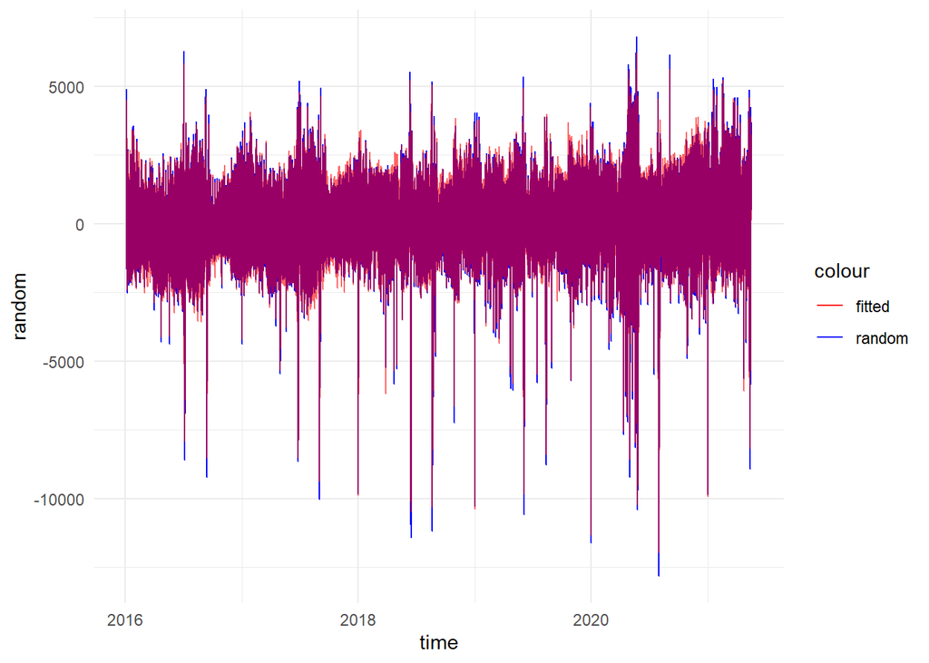

```r
model_fitted <- random_hd - residuals(model_arma44)

df <- cbind(hourly$date,as.data.frame(random_hd),as.data.frame(model_fitted))
colnames(df) <- c("time","random", "fitted")

color <- c(random="blue", fitted="red")

ggplot(df, aes(x=time))+
  geom_line(aes(y=random,color='random'))+
  geom_line(aes(y=fitted, color='fitted'), alpha=0.6)+
  scale_color_manual(values = color) +
  theme_minimal()
```

Model fits to the random component quite well.

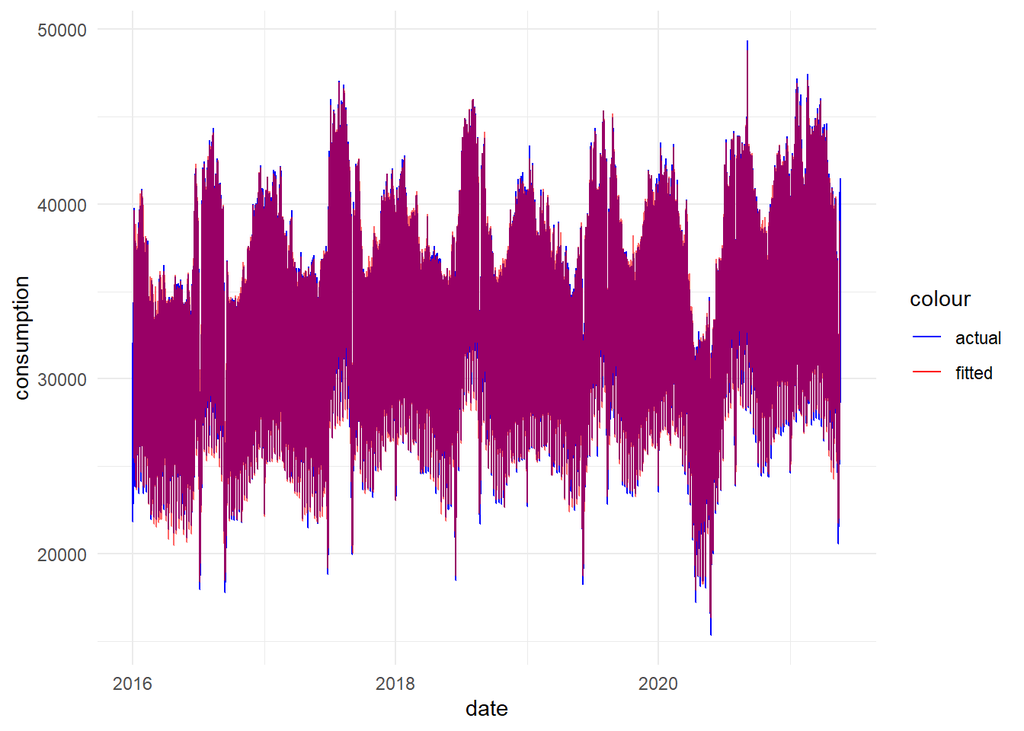

```r
model_fitted_transformed <- decomposed_hd$seasonal+decomposed_hd$trend+model_fitted
df2 <- cbind(hourly, model_fitted_transformed)

color <- c(actual="blue", fitted="red")

ggplot(df2, aes(x=date))+
  geom_line(aes(y=consumption,color='actual'))+
  geom_line(aes(y=model_fitted_transformed, color='fitted'), alpha=0.6)+
  scale_color_manual(values = color) +
  theme_minimal()
```

Actual and fitted series are quite similar.

### 3.5.3 Forecast

Since the frequency is set to 168, we have trend and seasonal components for all data points except the first 84 and last 84 ones. Seasonal component repeats itself, so we can simply reiterate it. Random component will be estimated by ARMA(4,4) model that we built in earlier sections. To estimate trend component, I have a few options. I can use the latest trend component or I can also build a model on trend. I decided to use `forecast()` function to estimate missing trend values.

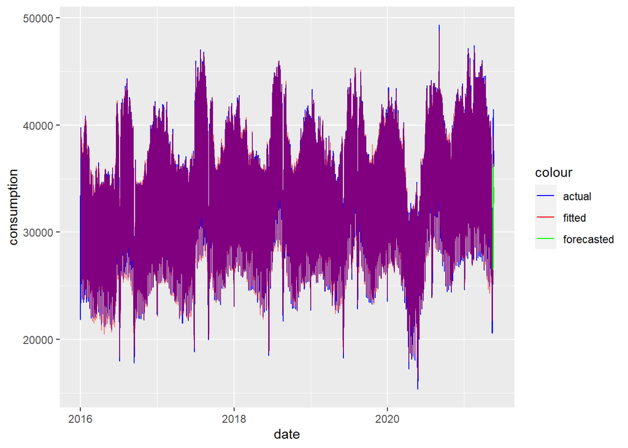

```r
forecasted_random <- as.numeric(forecast(model_arma44, h=84)$mean)
forecast_seasonal <- as.numeric(decomposed_hd$seasonal[85:168])
forecast_trend <- as.numeric(forecast(decomposed_hd$trend, h=84)$mean)
forecast <- forecasted_random+forecast_seasonal+forecast_trend
df2 <- cbind(df2, c(rep(NA, nrow(df2)-84),forecast))
colnames(df2)[4] <- "forecasted"

color <- c(actual="blue", fitted="red", forecasted="green")
ggplot(df2, aes(x=date))+
  geom_line(aes(y=consumption, color="actual"))+
  geom_line(aes(y=model_fitted_transformed, color="fitted"), alpha=0.5)+
  geom_line(aes(y=forecasted,color="forecasted"))+
  scale_color_manual(values = color)
```

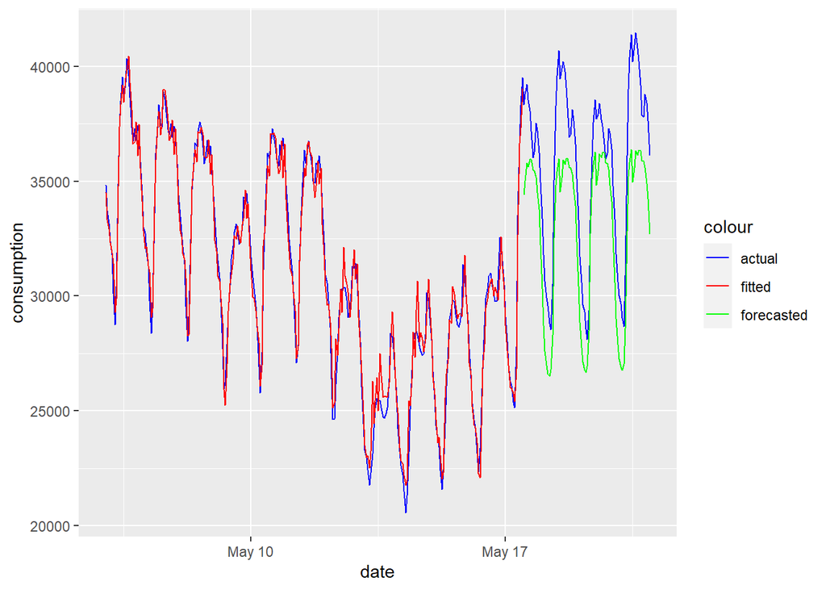

```r
df2 %>%
  filter(date>="2021-05-06 00:00:00") %>%
  ggplot(aes(x=date))+
  geom_line(aes(y=consumption, color="actual"))+
  geom_line(aes(y=model_fitted_transformed, color="fitted"))+
  geom_line(aes(y=forecasted,color="forecasted"))+
  scale_color_manual(values = color)
```

### 3.5.4 Evaluation

```r
accu<-function(actual,forecast){
  n=length(actual)
  error=actual-forecast
  mean=mean(actual)
  sd=sd(actual)
  CV=sd/mean
  FBias=sum(error)/sum(actual)
  MAPE=sum(abs(error/actual))/n
  RMSE=sqrt(sum(error^2)/n)
  MAD=sum(abs(error))/n
  MADP=sum(abs(error))/sum(abs(actual))
  WMAPE=MAD/mean
  l=data.frame(n,mean,sd,CV,FBias,MAPE,RMSE,MAD,MADP,WMAPE)
  return(l)
}
```

```r
df3 <- df2 %>%
  filter(date>="2021-05-06 00:00:00") %>%
  mutate(forecasted=ifelse(is.na(forecasted),model_fitted_transformed, forecasted)) %>%
  select(date, consumption, forecasted) %>%
  mutate(error=consumption-forecasted)
```

#### 3.5.4.1 Daily bias

```r
daily_bias <- df3 %>%
  group_by(date(date)) %>%
  summarise(error_sum=sum(error), actual_sum=sum(consumption)) %>%
  mutate(daily_bias=error_sum/actual_sum)

daily_bias
```

```
## # A tibble: 15 x 4
##    `date(date)` error_sum actual_sum daily_bias
##    <date>           <dbl>      <dbl>      <dbl>
##  1 2021-05-06       -532.    860488.  -0.000618
##  2 2021-05-07       -707.    845959.  -0.000836
##  3 2021-05-08       2461.    827047.   0.00298
##  4 2021-05-09       6043.    755011.   0.00800
##  5 2021-05-10       4315.    802693.   0.00538
##  6 2021-05-11       5911.    806919.   0.00733
##  7 2021-05-12      -4803.    704212.  -0.00682
##  8 2021-05-13     -14987.    602282.  -0.0249
##  9 2021-05-14     -10589.    625453.  -0.0169
## 10 2021-05-15      -3561.    652589.  -0.00546
## 11 2021-05-16       6073.    677636.   0.00896
## 12 2021-05-17      32780.    811242.   0.0404
## 13 2021-05-18      73651.    855113.   0.0861
## 14 2021-05-19      43240.    829748.   0.0521
## 15 2021-05-20      81312.    870574.   0.0934
```

#### 3.5.4.2 Daily mean absolute percentage error

```r
daily_mape <- df3 %>%
  group_by(date(date)) %>%
  summarise(daily_mape=sum(abs(error/forecasted))/24)

daily_mape
```

```
## # A tibble: 15 x 2
##    `date(date)` daily_mape
##    <date>            <dbl>
##  1 2021-05-06       0.0127
##  2 2021-05-07       0.0118
##  3 2021-05-08       0.0122
##  4 2021-05-09       0.0151
##  5 2021-05-10       0.0169
##  6 2021-05-11       0.0135
##  7 2021-05-12       0.0234
##  8 2021-05-13       0.0284
##  9 2021-05-14       0.0254
## 10 2021-05-15       0.0165
## 11 2021-05-16       0.0162
## 12 2021-05-17       0.0417
## 13 2021-05-18       0.0943
## 14 2021-05-19       0.0567
## 15 2021-05-20       0.102
```

#### 3.5.4.3 Weighted mean absolute percentage error

For the forecasted portion:

```r
accu(tail(df2$consumption,84),tail(df2$forecasted,84))
```

```
##    n     mean       sd        CV      FBias       MAPE     RMSE      MAD
## 1 84 35760.61 3850.679 0.1076793 0.07563392 0.07504962 2951.462 2704.715
##         MADP      WMAPE
## 1 0.07563392 0.07563392
```

For the fitted & forecasted portion of given period of the task:

```r
accu(tail(df2$consumption,14*24),c(df2$model_fitted_transformed[(nrow(df2)-14*24):(nrow(df2)-85)],df2$forecasted[(nrow(df2)-83):nrow(df2)]))
```

```
##     n     mean       sd        CV      FBias       MAPE     RMSE      MAD
## 1 336 31745.47 4940.118 0.1556165 0.02105683 0.04654832 1913.316 1495.315
##         MADP      WMAPE
## 1 0.04710327 0.04710327
```

In both, WMAPE values seem small, which is nice.

# 4 Conclusion

In this homework, I decomposed the time series into different levels. Then one of the decomposition is selected and a suitable ARMA model is built for the random component. Then I evaluated the model based on daily bias, daily mean absolute percentage error, and weighted mean absolute percentage error.

# 5 References

- (https://ibf.org/knowledge/glossary/weighted-mean-absolute-percentage-error-wmape-299)
- IE 360 Lecture notebooks